# ANALYSIS

## (THERE ARE) NO STUPID QUESTIONS

## Dependencies & Software Packages

- **[MDTraj](http://mdtraj.org/1.9.0/)**
- **[MDAanalysis](https://mdanalysis.org)**
- **[CHAP](https://github.com/channotation/chap)**
- **[GetContacts](https://getcontacts.github.io/)**
- **RainCloudPlots**
- NumPy, Matplotlib, Pandas, SciPy, MSMBuilder...

## Prerequisite

- Vaildate your simulations visually or with basic gmx tools  
  (gmx energy, gmx rms...)
- [Fix periodic boundry condition](http://www.gromacs.org/Documentation/Terminology/Periodic_Boundary_Conditions)

[figure not shown]

-> pore hydration

-> helix tilt, twist

-> principal components

-> other gating free energy landscape coordinates

> - A Protein is a Set Of Coordinates.

>   ```
>     A.P. Heiner
>   ```

## Data Structure

- **Pandas**

```python
md_data = pd.read_pickle('../open_glic_intrawater.pickle')
```

```python
md_data.head()
```

|  | MD_name | pH | replicate | subunit | traj_time | system | rmsd | ecd_rmsd | tmd_rmsd | ecd_pc1 | ... | intra_water_bridge_263_243 | intra_water_bridge_263_239 | intra_water_bridge_235_259 | intra_hbond_235_259 | inter_hbond_230_233 | inter_water_bridge_230_233 | inter_water_bridge_196_243 | inter_hbond_196_243 | inter_hbond_196_249 | intra_hbond_234_238 |
| --- | --- | --- | --- | --- | --- | --- | --- | --- | --- | --- | --- | --- | --- | --- | --- | --- | --- | --- | --- | --- | --- |
| 1 | 4HFI | 46 | 1 | 0 | 0 | 0 | 0.00000 | 0.000000 | 0.007192 | -0.218533 | ... | 0 | 0 | 0 | 1 | 0 | 0 | 0 | 0 | 0 | 1 |
| 2 | 4HFI | 46 | 1 | 1 | 0 | 0 | 0.01253 | 0.000000 | 0.007192 | -0.153843 | ... | 0 | 0 | 0 | 1 | 0 | 0 | 0 | 0 | 1 | 1 |
| 3 | 4HFI | 46 | 1 | 2 | 0 | 0 | 0.00000 | 0.008101 | 0.010171 | -0.187962 | ... | 0 | 0 | 0 | 1 | 0 | 0 | 0 | 0 | 0 | 1 |
| 4 | 4HFI | 46 | 1 | 3 | 0 | 0 | 0.01253 | 0.011457 | 0.000000 | -0.129403 | ... | 0 | 0 | 0 | 1 | 0 | 0 | 1 | 0 | 1 | 1 |
| 5 | 4HFI | 46 | 1 | 4 | 0 | 0 | 0.00000 | 0.000000 | 0.000000 | -0.162889 | ... | 0 | 0 | 0 | 1 | 0 | 0 | 0 | 0 | 0 | 1 |

5 rows × 50 columns

## Analysis tools

### Root-mean-square deviation (RMSD) and Root-mean-square fluctuation (RMSF)

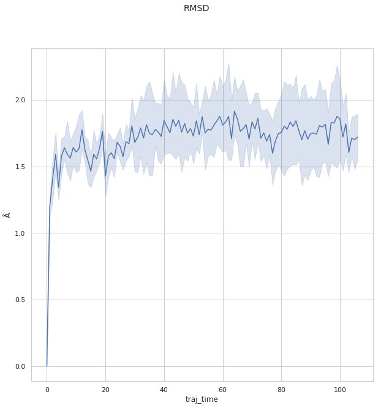

```python
plot_rmsd()
```

[figure not shown]

#### Tools

- gmx rms
- gmx rmsf
- MDTraj

```
traj = md.load(traj_location,top = top_location)
ref_traj = md.load(ref_location)
traj.superpose(ref_traj)
rmsd_data.extend(list(md.rmsd(traj, ref_traj)))
```

[figure not shown]

### Geomtric features

- Domain twist

[figure not shown]

http://stb.proteinart.net/analysis.html

- helix tilt, twist

[figure not shown]

#### Tools

- vmd (tcl scripts)
- MDTraj
  - M1 kink

```
for chain in range(0,5):
    M1_selection_up = 'resid ' + str(195 + chain * 311) + ' to ' + str(199 + chain * 311)
    M1_selection_mid = 'resid ' + str(197 + chain * 311) + ' to ' + str(201 + chain * 311)
    M1_selection_down = 'resid ' + str(200 + chain * 311) + ' to ' + str(211 + chain * 311)

    M1_up = traj.atom_slice(topology.select(M1_selection_up))
    M1_mid = traj.atom_slice(topology.select(M1_selection_mid))
    M1_down = traj.atom_slice(topology.select(M1_selection_down))
    angle.append(angle_calculate(md.compute_center_of_mass(M1_up),
                                 md.compute_center_of_mass(M1_mid),
                                 md.compute_center_of_mass(M1_down)))
```

- M1(n) - M2(n+1) distance

```
subunit_dic = {0:0,1:1,2:2,3:3,4:4,5:0}

for subunit in range(0,5):

    M1_selection = 'resid ' + str(195 + subunit_dic[subunit] * 311) +
                            ' to ' + str(199 + subunit_dic[subunit] * 311)
    M2_selection = 'resid ' + str(236 + (subunit_dic[subunit+1]) * 311) +
                            ' to ' + str(240 + (subunit_dic[subunit+1]) * 311)
    traj_M1 = traj.atom_slice(topology.select(M1_selection))
    traj_M2 = traj.atom_slice(topology.select(M2_selection))
    distance.append(distance_cal(md.compute_center_of_mass(traj_M1).T,md.compute_center_of_mass(traj_M2).T))
```

### "Functional" features

- Hydration of pore
- Principal component analysis
- Collective variables

#### Tools

- vmd
- MDAanalysis
  - Pore hydration

    ```
    traj = mda.Universe(top_location, traj_location)
    hydration = traj.select_atoms("(cyzone 7 8 -8 resid 236) and name OW",updating = True)
    for i in range(0,traj.trajectory.n_frames):
    traj.trajectory[i]
    hydration_data.append(hydration.n_atoms)
    ```

- Chap

[figure not shown]

- mdtraj
  - PCA

ecd_pc1

[figure not shown]

tmd_pc1

[figure not shown]

```
[ 0.67002451  0.20237772]
```

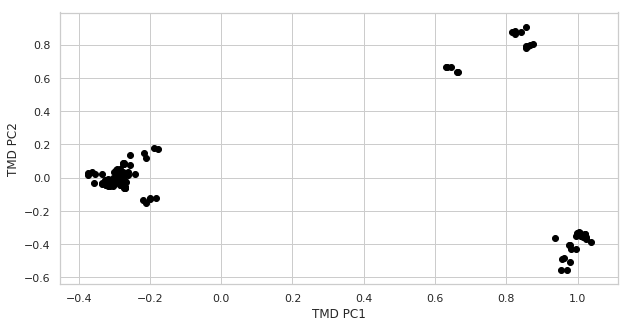

```python
tmd_traj = md.load('/home/scottzhuang/masterthesis/miscellanies/pdb_ensemble/ensemble_subunit_tmd.pdb')
ppca_tmd = PCA(n_components=2)
partial_reduced_cartesian = ppca_tmd.fit_transform(tmd_traj.xyz.reshape(tmd_traj.n_frames, tmd_traj.n_atoms * 3))
print(ppca_tmd.explained_variance_ratio_)
fig, ax = plt.subplots(figsize=(10, 5))
#md_data[(md_data.system == 0)].plot(kind='scatter', x = 'tmd_pc1', y = 'tmd_pc2',ax = ax, c= 'traj_time',colormap='Blues',colorbar=None)
ax.scatter(partial_reduced_cartesian.T[0], partial_reduced_cartesian.T[1],c = 'black')
ax.set_xlabel('TMD PC1')
ax.set_ylabel('TMD PC2')
plt.show()
```

### "Chem" features

- Electrostatic interactions
- Hydrophobic interactions

[ref](https://getcontacts.github.io/interactions.html)

#### Tools

- MDAanalysis
  - Hbond and water bridge

```
traj = mda.Universe(location + top_location,location + traj_location)
h =  HydrogenBondAnalysis(traj, 'resid 192:315', 'resid 192:315',
                   selection1_type='donor', distance=3.5, angle=120.0,
                     distance_type='heavy')
h.run()
h.generate_table()
df = pd.DataFrame.from_records(h.table)
df.to_csv(location + traj_note + "/hbond_tmd.csv")
```

- GetContacts

[figure not shown]

## Visualization

### Line plot

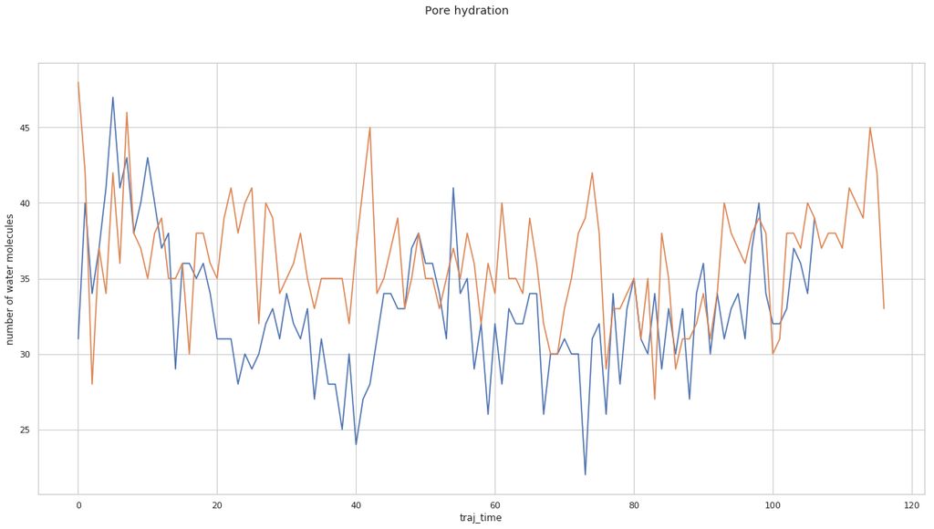

```python
fig, ax = plt.subplots(figsize=(20, 10))
sns.lineplot(x='traj_time',y='pore_hydration',data=md_data[(md_data.system == 0) & (md_data.replicate == 1)],palette='Set2',ax=ax)
sns.lineplot(x='traj_time',y='pore_hydration',data=md_data[(md_data.system == 2) & (md_data.replicate == 1)],palette='Set2',ax=ax)
plt.suptitle('Pore hydration')
ax.set_ylabel('number of water molecules')
plt.show()
```

### Histogram plot

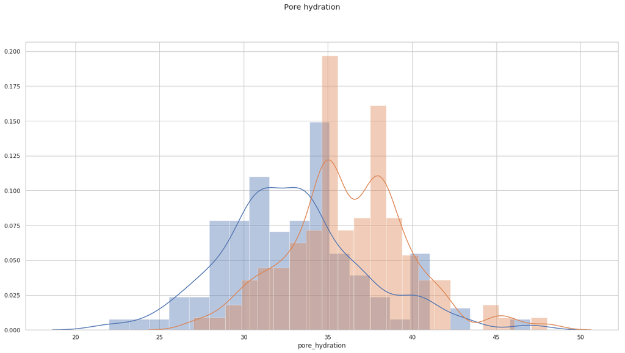

```python
fig, ax = plt.subplots(figsize=(20, 10))
sns.distplot(md_data[(md_data.system == 0) & (md_data.replicate == 1)]['pore_hydration'],ax=ax)
sns.distplot(md_data[(md_data.system == 2) & (md_data.replicate == 1)]['pore_hydration'],ax=ax)
plt.suptitle('Pore hydration')
plt.show()
```

### Bar plot

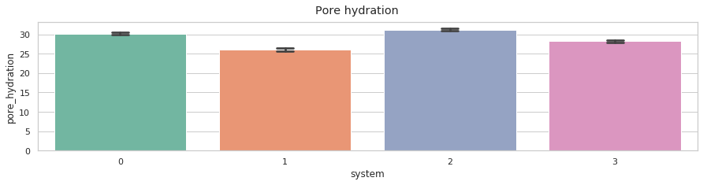

```python
fig, ax = plt.subplots(figsize=(15, 3))
sns.barplot(x='system',y='pore_hydration',data=md_data[(md_data.traj_time > 40)],palette='Set2',capsize=.1,)
#            hue='replicate')
plt.suptitle('Pore hydration')
plt.show()
```

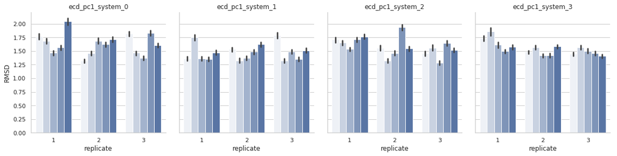

```python
g = sns.FacetGrid(md_data, col = "system", height = 4)
g = g.map_dataframe(sns.barplot, x = "replicate", y = 'rmsd',hue='subunit',data = md_data)
g = g.set_titles('ecd_pc1' + "_system_{col_name}")
g = g.set_axis_labels(x_var='replicate', y_var = 'RMSD')
```

### Raincloud plot

[ref](https://github.com/RainCloudPlots/RainCloudPlots)

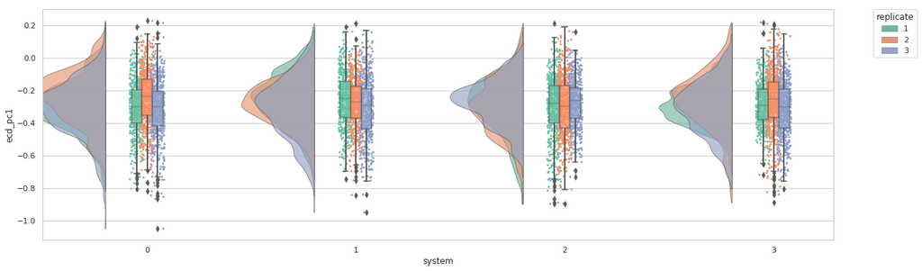

```python
fig, ax = plt.subplots(figsize=(20, 6))
pt.RainCloud(x = 'system', y = 'ecd_pc1', hue='replicate',data = md_data,
                palette = 'Set2', bw = .2,width_viol = .7,ax=ax,alpha = .65,dodge = True,pointplot=False)
plt.show()
```

## Miscellaneous

- Å or nm
- ps or ns or μs
- clockwise or anticlockwise
- residue or resSeq or ...
- pdb or gro

colorful

[figure not shown]

colorless

[figure not shown]

### Other featuralizers/clusterers/modellers

[MSMBuilder](http://msmbuilder.org/3.8.0/)

| Featurizer | Notes |
| --- | --- |
| ContactFeaturizer | Featurizer based on residue-residue distances. |
| DihedralFeaturizer | Featurizer based on dihedral angles. |
| ... | ... |

| Clusterer | Notes |
| --- | --- |
| KCenters | K-Centers clustering |
| GMM | Gaussian Mixture |
| ... | ... |

- [fpocket2/MDpocket](http://fpocket.sourceforge.net/)
- [scikit-learn](https://scikit-learn.org/)

### Speed up your code

```
from joblib import Parallel, delayed
import multiprocessing
num_cores = multiprocessing.cpu_count()
Parallel(n_jobs=num_cores-2)(delayed(calculate_H_Bond)(traj) for traj in all_trajs)
```

### Statistics for birdwatchers

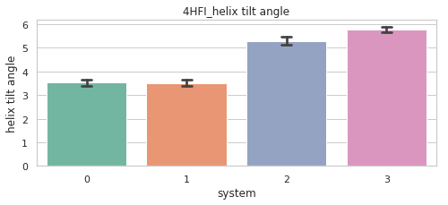

```python
fig, ax = plt.subplots(figsize=(8, 3))
ax.set_title('4HFI_' + 'helix tilt angle')
sns.barplot(x='system',y='helix tilt angle',
            data=md_data[(md_data.traj_time > 30)],

            palette='Set2',capsize=.1)
plt.show()
```

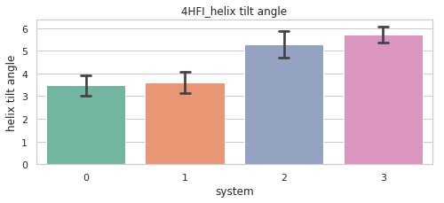

```python
fig, ax = plt.subplots(figsize=(8, 3))
ax.set_title('4HFI_' + 'helix tilt angle')
sns.barplot(x='system',y='helix tilt angle',
            data=md_data[(md_data.traj_time > 30)
            & (md_data.traj_time % 10 == 0)],
            palette='Set2',capsize=.1)
plt.show()
```

Calculation of standard deviation assumes our snapshots being independent from each other.

- For each property there is a correlation/relaxation time
- This is usually unknown or even the subject of the study

[ref](http://www.courses.physics.helsinki.fi/fys/moldyn/lectures/L6.pdf)